# Final Project

You will be asked to download data by yourselves and answer several data science questions through this final project. This project has two parts.

## Part 1 (15 Points):

This part contains 10 different data science questions that you are asked to answer. You need to download the corresponding data and write code to process the data to answer these questions. For each question, you need to provide your code to anser this question, as well as final answers. Each question will be worth 1.5 points in this part.

## Final Submission:

Your final submission will contain two files:

1. The first would be this notebook. You need to provide code for your answers as well as your answers. You also need to provide visualization and executive summary using Markdown in this notebook.
2. The second is the html version of this notebook.

## Part 1

First, you need to download the most recent datasets containing listing and reviews in **Los Angeles** from [insidearibnb.com](http://insideairbnb.com/get-the-data.html). (September,2019,detailed data)You will then need to provide the code as well as answers to the following questions.

**To make sure that you downloaded the right dataset, your solution to Question 1 should be:**

1. **Number of unique listings = 45053**
2. **Number of unique hosts = 26286**

### Question 1: How many unique listings are there in the LA dataset? How many unique hosts are there?

**Question 1 Answer:**

The unique number of listings in the LA area is 45053. The unique number of IDs in the LA area is 26286.

```python
# You need to provide the code to answer the previous quesiton
# (you should also briefly explain your data structure --
# where do you put your data and how you get your data)

import pandas as pd

df_listings = pd.read_csv("listings.csv")

#We used .nunique() to get the unique listing number, which is stored in num_unique_listing
#We used .nunique() to get the unique host number, which is stored in num_unique_host

num_unique_listing = df_listings["id"].nunique()
num_unique_host = df_listings["host_id"].nunique()
print("The unique number of listings in the LA area is %i." % num_unique_listing)
print("The unique number of IDs in the LA area is %i." % num_unique_host)
```

```
The unique number of listings in the LA area is 45053.
The unique number of IDs in the LA area is 26286.
```

### Question 2: What is the mean, median, standard deviation, minimum and maximum of the number of listings per host in LA? (for each host, you only need to consider the listings from LA)

**Question 2 Answer:**

The mean, standard deviation, minimum and maximum of the number of listings per host in LA are 1.71, 3.00, 1.00, 1.00 and 172.00.

```python
# You need to provide the code to answer the previous quesiton
import pandas as pd

df_listings = pd.read_csv("listings.csv")

#We first used .drop_duplicates() to get unique rows based on 'host_id', and then used .describe() to get basic statistics
num_listing_perhost_summary = df_listings.drop_duplicates(keep="first", subset=["host_id"])["calculated_host_listings_count"].describe()
num_listing_perhost_median = df_listings.drop_duplicates(keep="first", subset=["host_id"])["calculated_host_listings_count"].median()
print("median       %s" %num_listing_perhost_median)
num_listing_perhost_summary
```

```
median       1.0
```

```
count    26286.000000
mean         1.713954
std          2.999183
min          1.000000
25%          1.000000
50%          1.000000
75%          1.000000
max        172.000000
Name: calculated_host_listings_count, dtype: float64
```

### Question 3: What is the average and standard deviation number of listings for a super host versus a non-super host? Does super host or non-super host have more listings on average?

**Question 3 Answer:**

The average and standard deviation number of listings for a super host versus a non-super host are 1.82, 1.67, 3.18 and 2.93.\ Super host has more listings on average.

```python
# You need to provide the code to answer the previous quesiton
import pandas as pd
import numpy as np

df_listings = pd.read_csv("listings.csv")
# We first used the column "host_is_superhost" as the indentifier to screen out the two different catagories
# We then used the apply function with multiple functions to get the data

df_unique = df_listings.drop_duplicates(keep="first", subset=["host_id"])
df_unique.groupby(by = 'host_is_superhost').apply\
(lambda x: pd.Series({"mean" : np.mean(x["calculated_host_listings_count"]),\
                                                               "std" : np.std(x["calculated_host_listings_count"])}))
```

| host_is_superhost | mean | std |
| --- | --- | --- |
| f | 1.671021 | 2.926198 |
| t | 1.824264 | 3.177677 |

### Question 4: What are the unique types of host verifications are there? (It doesn't matter if you include "None" or empty string as a type)

**Question 4 Answer:**

The unique types of host verifications are:\ 'email',\ 'phone',\ 'facebook',\ 'reviews',\ 'kba',\ 'jumio',\ 'government_id',\ 'offline_government_id',\ 'selfie',\ 'identity_manual',\ 'work_email',\ 'manual_online',\ 'manual_offline',\ 'google',\ '',\ 'sent_id',\ 'None',\ 'sesame',\ 'sesame_offline',\ 'photographer',\ 'zhima_selfie',\ 'weibo'.

```python
# You need to provide the code to answer the previous quesiton

import pandas as pd

df_listings = pd.read_csv("listings.csv")

#We used lst_veri to store the unique verification types, and we wrote a for loop to clean the strings and\
#to get the unique types
lst_veri = []
for i in df_listings["host_verifications"].unique().tolist():
    veri = i.strip("[").strip("]").strip("'").split("', '")
    for j in veri:
        if j not in lst_veri:
            lst_veri.append(j)

print("There are %i kinds of verification methods." %len(lst_veri))
print("Methods are listed below:")
lst_veri
```

```
There are 22 kinds of verification methods.
Methods are listed below:
```

```
['email',
 'phone',
 'facebook',
 'reviews',
 'kba',
 'jumio',
 'government_id',
 'offline_government_id',
 'selfie',
 'identity_manual',
 'work_email',
 'manual_online',
 'manual_offline',
 'google',
 '',
 'sent_id',
 'None',
 'sesame',
 'sesame_offline',
 'photographer',
 'zhima_selfie',
 'weibo']
```

### Question 5: What are the five most popular verification types of hosts? For each type of the top five verifications, how many percent of hosts verify that type?

**Question 5 Answer:**

The five most popular verification types of hosts are phone, email, reviews, government_id and jumio.\ The percent of hosts verifying each type are 99.68%, 93.84%, 68.86%, 58.77%, 43.34% respectively.

```python
# You need to provide the code to answer the previous quesiton

#Note: before running this chunk, the chunk of question 4 needs to be run first

# Created a dictionary to store the count of different verfication methods' appearances
dic_veri = {}
for i in lst_veri:
    if i not in dic_veri.keys():
        dic_veri[i] = 0

#drop duplicates and store the column 'host_verifications' into variable temp
temp = df_listings.drop_duplicates(keep="first", subset = ["host_id", "host_verifications"])["host_verifications"]

#clean variable temp
for i in temp:
    veri = i.strip("[").strip("]").strip("'").split("', '")
    for j in veri:
        dic_veri[j] += 1

#choose the top 5 verification methods and store them along with the counts into variable dic_veri_top5
lst_veri_top5 = sorted(dic_veri.items(), key=lambda x: x[1], reverse=True)[0:5]
dic_veri_top5 = {}
for i in lst_veri_top5:
    dic_veri_top5[i[0]] = i[1]

#because there are 26286 unique hosts in total, so we calculate the percentages using counts divided by 26286
dic_veri_top5 = pd.DataFrame(pd.Series(dic_veri_top5)).rename(columns={0:'count'})
dic_veri_top5['percentage'] = dic_veri_top5['count']/26286

#At last, the answer to question 5 is stored in variable dic_veri_top5
dic_veri_top5
```

|  | count | percentage |
| --- | --- | --- |
| phone | 26201 | 0.996766 |
| email | 24666 | 0.938370 |
| reviews | 18099 | 0.688541 |
| government_id | 15448 | 0.587689 |
| jumio | 11392 | 0.433387 |

### Question 6: What is the mean, standard deviation of the average price of a listing in Los Angles from 01/01/2020 to 03/01/2020 (inclusive)? (For listings that are not available in this time, you should not count them in the average price.)

**Question 6 Answer:**

The mean, standard deviation of the average price of a listing in Los Angles from 01/01/2020 to 03/01/2020 (inclusive) are 257.890021 and 10.209746.

```python
# You need to provide the code to answer the previous quesiton
import pandas as pd
import numpy as np

df_calendar = pd.read_csv("calendar.csv")
#just in case, set column 'date' format
df_calendar['date'] = pd.to_datetime(df_calendar['date'])
#create filter setting in mask
mask = (df_calendar['date']>='2020-01-01') & (df_calendar['date']<='2020-03-01') & (df_calendar['available']=='t')
#filter rows and store into df_calendar_range
df_calendar_range = df_calendar.loc[mask]
#clean column 'price'
df_calendar_range['price'] = df_calendar_range['price'].str.replace("$","").str.replace(",","")
df_calendar_range = df_calendar_range.reset_index(drop=True)
#set the format of column 'price' to float
df_calendar_range['price'] = df_calendar_range['price'].astype(float)

#use numpy to calculate the mean and standard deviation of the mean of prices grouped according to different dates
df_calendar_range.groupby(by=['date'])['price'].mean().agg([np.mean, np.std])
```

```
mean    257.890021
std      10.209746
Name: price, dtype: float64
```

### Question 7: For reviews that are written in Jan, 2016, what are the most popular ten words except stopping words? What about reviews written in March, 2017 and April, 2018?

**Hint**: You need to use NTLK stopping words to find the stopping words in Python. You also need to remove punctuation and numbers

**Question 7 Answer:**

The most popular ten words in **Jan 2016**: great, stay, place, location, clean, house, us, nice, would, host (ordered by counts from high to low).

The most popular ten words in **March 2017**: great, place, stay, location, clean, nice, would, host, house, comfortable (ordered by counts from high to low).

The most popular ten words in **April 2018**: great, place, stay, location, clean, would, host, nice, la, house (ordered by counts from high to low).

```python
# You need to provide the code to answer the previous quesiton

import pandas as pd
import nltk
from nltk.corpus import stopwords
from nltk.tokenize import word_tokenize
import string

# Set the stop words and the punctuations for later filtering
stop_words = set(stopwords.words('english'))
punctuations = set(string.punctuation)

df_reviews = pd.read_csv("reviews.csv")

#create a function to get the most popular 10 words in different time; the input is the time filters
def get_top10words_review(mask):

    #filter rows
    df_reviews_range = df_reviews.loc[mask]
    df_reviews_range.reset_index(drop=True, inplace=True)
    #create a copy for the convenience of debug
    df_reviews_range_temp = df_reviews_range.copy()

    #use iteration to get the sorted sequence of words according to counts
    for index, row in df_reviews_range_temp.iterrows():
        #the non-stopwords version of different reviews is stored in review_nonstopwords
        review_nonstopwords = ' '
        #pick out the review in different rows and set the format to be string for later methods
        review = str(row["comments"])

        #the non-punctuation version of different reviews is stored in review_nonpunctuations
        review_nonpunctuations = ''.join(w.lower() for w in review if w not in punctuations).split(" ")

        #use a for loop to get rid of stopwords
        for w in review_nonpunctuations:
            if w not in stop_words:
                review_nonstopwords = review_nonstopwords + ' ' + w

        #clean the column 'comments'
        df_reviews_range_temp.loc[index, 'comments'] = review_nonstopwords

    #pick out the 10 most popular words, and store the result into count
    count = pd.Series(' '.join(df_reviews_range_temp['comments']).lower().split()).value_counts()[:10]

    return count

mask_1 = (df_reviews['date']>='2016-01-01') & (df_reviews['date']<='2016-01-31')
mask_2 = (df_reviews['date']>='2017-03-01') & (df_reviews['date']<='2017-03-31')
mask_3 = (df_reviews['date']>='2018-04-01') & (df_reviews['date']<='2018-04-30')

print("The most popular ten words in Jan 2016:" )
print(get_top10words_review(mask_1))
print("The most popular ten words in March 2017:" )
print(get_top10words_review(mask_2))
print("The most popular ten words in April 2018:" )
print(get_top10words_review(mask_3))
```

```
The most popular ten words in Jan 2016:
great       5421
stay        4707
place       4321
clean       2744
location    2744
house       2674
us          2645
nice        2423
would       2416
host        2349
dtype: int64
The most popular ten words in March 2017:
great          12253
place          11567
stay            9508
location        5920
clean           5478
nice            4566
would           4565
host            4474
house           3801
comfortable     3797
dtype: int64
The most popular ten words in April 2018:
great       18942
place       18728
stay        14806
location    10089
clean        9097
would        7398
host         6854
nice         6836
la           5603
house        5568
dtype: int64
```

### Question 8: Which five zipcode has the highest average listing price and has at least 30 listings (again only considering available dates) between 2020-01-01 to 2020-02-01 (inclusive)? What are these listing prices? What are the number of active listings and number of hosts in these top five zipcodes (a listing is active if it has at least one available date in the calendar data)?

**Question 8 Answer:**\ The result is as follows:

```
                        zipcode  price         num_active_listings  num_hosts
                        90210   1926.469725  278                    173
                        90077   1832.004457  74                  48
                        90265   1547.648483  329                    221
                        90069   949.920967    426                   306
                        91436   639.542918    40                     33
```

```python
# You need to provide the code to answer the previous quesiton
import pandas as pd
df_calendar = pd.read_csv("calendar.csv")
df_listings = pd.read_csv("listings.csv")

#just in case, set column 'date' format
df_calendar["date"] = pd.to_datetime(df_calendar["date"])
#filter rows and store into df_calendar_range
df_calendar_range = df_calendar[(df_calendar['date'] >= "2020-01-01") & (df_calendar['date'] <= "2020-02-01") & (df_calendar['available'] == "t")]
#clean column 'zipcode'
df_listings['zipcode'] = df_listings['zipcode'].str.strip("CA ")\
                                               .str.strip("Near ")\
                                               .str.strip(" -This is the address to our main house. The studio is located behind our house off of Stimson")

#choose needed columns and store them into df_listings_slice, so that codes can run faster
df_listings_slice = df_listings[["id","zipcode","host_id"]]

#use left merge on df_calendar_range and df_listings_slice, based on listing id; store the result into df_combined
df_combined = df_calendar_range.merge(df_listings_slice, how = "left", left_on = "listing_id", right_on = "id")

#filter rows with no fewer than 30 listings in different zipcodes
df_combined = df_combined.groupby("zipcode").filter(lambda x: x['listing_id'].nunique() >= 30)
#clean column 'price'
df_combined['price'] = df_combined['price'].str.replace("$", "").str.replace(",","").astype(float)

#calculate the mean of price of different listing ids across different zipcodes
df_rank = pd.DataFrame(df_combined.groupby(by=['zipcode', 'listing_id'])['price'].mean())
#calculate the mean of price in different zipcodes
df_rank = pd.DataFrame(df_rank.groupby(by='zipcode')['price'].mean())
#rank the price
df_rank.sort_values('price', inplace=True, ascending=False)
#choose the 5 zipcodes with highest average price
df_rank_top5 = df_rank.head(5)

#calculate the number of unique listings across zipcodes
df_rank_top5['num_active_listings'] = df_combined.groupby(by='zipcode')['listing_id'].nunique()
#calculate the number of unique host ids across zipcodes
df_rank_top5['num_hosts'] = df_combined.groupby(by='zipcode')['host_id'].nunique()

#the result dataframe is stored in df_rank_top5
df_rank_top5
```

| zipcode | price | num_active_listings | num_hosts |
| --- | --- | --- | --- |
| 90210 | 1926.469725 | 278 | 173 |
| 90077 | 1832.004457 | 74 | 48 |
| 90265 | 1547.648483 | 329 | 221 |
| 90069 | 949.920967 | 426 | 306 |
| 91436 | 639.542918 | 40 | 33 |

### Question 9: Focusing on the data from 2020-01-01 to 2020-04-01 (inclusive), what are five zipcodes that have at least 30 listings and have the largest absolute difference between the average prices on weekends versus the average prices on weekdays? (Weekends = Saturday and Sunday). Please give the zipcodes as well as the listing prices

**Question 9 Answer:**\ The result is as follows:

```
                    zipcode  abs_difference weekday_pricemean   weekend_pricemean
                    91384   22.547185        138.430670        160.977855
                    90265   20.103059        1397.389489          1417.492548
                    90210   10.723267        1620.193908          1630.917175
                    91325   9.428009          220.009608           229.437617
                    90293   8.973894          246.446374           255.420268
```

```python
# You need to provide the code to answer the previous quesiton

import pandas as pd
df_calendar = pd.read_csv("calendar.csv")
df_listings = pd.read_csv("listings.csv")

#just in case, set column 'date' format
df_calendar["date"] = pd.to_datetime(df_calendar["date"])
#filter rows and store into df_calendar_range
df_calendar_range = df_calendar[(df_calendar['date'] >= "2020-01-01") & (df_calendar['date'] <= "2020-04-01")]
#clean column 'zipcode'
df_listings['zipcode'] = df_listings['zipcode'].str.strip("CA ")\
                                               .str.strip("Near ")\
                                               .str.strip(" -This is the address to our main house. The studio is located behind our house off of Stimson")

#choose needed columns and store them into df_listings_slice, so that codes can run faster
df_listings_slice = df_listings[["id","zipcode","host_id"]]

#use left merge on df_calendar_range and df_listings_slice, based on listing id; store the result into df_combined
df_combined = df_calendar_range.merge(df_listings_slice, how = "left", left_on = "listing_id", right_on = "id")

#filter rows with no fewer than 30 listings in different zipcodes
df_combined = df_combined.groupby("zipcode").filter(lambda x: x['listing_id'].nunique() >= 30)
#clean column 'price'
df_combined['price'] = df_combined['price'].str.replace("$", "").str.replace(",","").astype(float)

#use .dt.dayofweek to find out the day of the week at each date, then store the result in column 'day_inaweek'
df_combined['day_inaweek'] = pd.Series(df_combined['date']).dt.dayofweek
#use 'day_inaweek' to create a new column 'dayofweek' which tells the english instead of numeric version of days
df_combined['dayofweek'] = df_combined['day_inaweek'].apply(lambda x: 'weekday' if x <= 4 else 'weekend')

#calculate the mean of different days in a week across different zipcodes
df_combined_pricemean = pd.DataFrame(df_combined.groupby(by=['zipcode', 'dayofweek'])['price'].mean()).reset_index()
#set out the weekday rows to df_combined_pricemean_weekday
df_combined_pricemean_weekday = df_combined_pricemean[df_combined_pricemean['dayofweek']=='weekday']
#set out the weekend rows to df_combined_pricemean_weekday
df_combined_pricemean_weekend = df_combined_pricemean[df_combined_pricemean['dayofweek']=='weekend']
#store the zipcodes into df_combined_difference and set 'zipcode' as index, for later's convenience
df_combined_difference = pd.DataFrame(df_combined_pricemean_weekday['zipcode']).set_index('zipcode')
#set 'zipcode' as index, for later's convenience
df_combined_pricemean_weekday.set_index('zipcode', inplace=True)
df_combined_pricemean_weekend.set_index('zipcode', inplace=True)

#calculate the difference of average price between weekday and weekend across zipcodes
#because the index is zipcode, we don't need to bother corrsponding again
df_combined_difference['abs_difference'] = abs(df_combined_pricemean_weekday['price'].astype(float) - \
                                           df_combined_pricemean_weekend['price'].astype(float))

#sort the difference based on absolute values of price differences
df_combined_difference.sort_values('abs_difference', inplace=True, ascending=False)
#add average price of weekdays and weekends across zipcodes into the dataframe
df_combined_difference['weekday_pricemean'] = df_combined_pricemean_weekday['price']
df_combined_difference['weekend_pricemean'] = df_combined_pricemean_weekend['price']
#display the five zipcodes with highest absolute average price differences between weekdays and weekends
df_combined_difference.head(5)
```

| zipcode | abs_difference | weekday_pricemean | weekend_pricemean |
| --- | --- | --- | --- |
| 91384 | 22.547185 | 138.430670 | 160.977855 |
| 90265 | 20.103059 | 1397.389489 | 1417.492548 |
| 90210 | 10.723267 | 1620.193908 | 1630.917175 |
| 91325 | 9.428009 | 220.009608 | 229.437617 |
| 90293 | 8.973894 | 246.446374 | 255.420268 |

### Question 10: What is the average and standard deviation of the daily total capacity at Airbnb Los Angeles from 2020-01-01 to 2020-04-01? The daily total capacity in a day is the number of beds that are available in that given date. What is the average and standard deviation of the daily price per bed at Airbnb Los Angeles from 2020-01-01 to 2020-04-01?

**Question 10 Answer:**\ The total capacity mean is 46995.23,\ The total capacity standard deviation is 4980.64,\ The daily price per bed mean is 113.22,\ The daily price per bed standard deviation is 4.55.

```python
# You need to provide the code to answer the previous quesiton

import pandas as pd
df_calendar = pd.read_csv("calendar.csv")
df_listings = pd.read_csv("listings.csv")

#just in case, set column 'date' format
df_calendar["date"] = pd.to_datetime(df_calendar["date"])
#filter rows and store into df_calendar_range
df_calendar_range = df_calendar[(df_calendar['date'] >= "2020-01-01") & (df_calendar['date'] <= "2020-04-01") & (df_calendar['available']=='t')]
#choose needed columns and store them into df_listings_slice, so that codes can run faster
df_listings_slice = df_listings[["id", "beds"]]

#use left merge on df_calendar_range and df_listings_slice, based on listing id; store the result into df_combined
df_combined = df_calendar_range.merge(df_listings_slice, how = "left", left_on = "listing_id", right_on = "id")
#clean column 'price'
df_combined['price'] = df_combined['price'].str.replace("$", "").str.replace(",","").astype(float)

#choose needed columns and store them into df_combined, then get rid of rows having no value or zero in column 'beds'
df_combined = df_combined[['listing_id', 'date', 'price', 'beds']][df_combined['beds']>0]
#calculate total capacity at different dates
total_capacity = df_combined.groupby(by='date')['beds'].sum()
#calculate price per bed
df_combined['price_per_bed'] = df_combined['price']/df_combined['beds']
#calculate price per bed at different dates
daily_price_per_bed = df_combined.groupby(by='date')['price_per_bed'].mean()

print('The average of daily total capacity is %0.4f'%total_capacity.mean())
print('The standard deviation of daily total capacity is %0.4f'%total_capacity.std())
print('The average of daily price per bed is %0.4f'%daily_price_per_bed.mean())
print('The standard deviation of daily price per bed is %0.4f'%daily_price_per_bed.std())
```

```
The average of daily total capacity is 46995.2283
The standard deviation of daily total capacity is 4980.6413
The average of daily price per bed is 113.2221
The standard deviation of daily price per bed is 4.5497
```

## Part 2 (15 Points):

In this part, you need to find **5** interesting business questions out of the datasets. You then need to write Python code to answer the questions. Last, you need to write a 200-word summary of your answers and business insights you get from ansewr these 5 questions baed on your code. You will be evaluated based on the following criterion:

1. You need to ask three business-relevant questions (2 points)
2. You need to answer these three questions using Python and the datasets (1 points)
3. You have at least **5** graphs to visualize your insights (2 points)
4. Your executive summary of your answers are well-written and make sense (5 points)
5. Your business insights are very interesting and the report is creative (5 points)

### Question 1: What are the top 5 most common amenities in the apartment-for-rent? What about their percentage in the overall listings? What changes should be made to improve the overall expereince for renter?

```
                  num_of_items  percentage_of_item
Wifi                     43963            0.975806
Essentials               42857            0.951257
"Smoke detector"         41690            0.925355
Kitchen                  39936            0.886423
Heating                  39722            0.881673
```

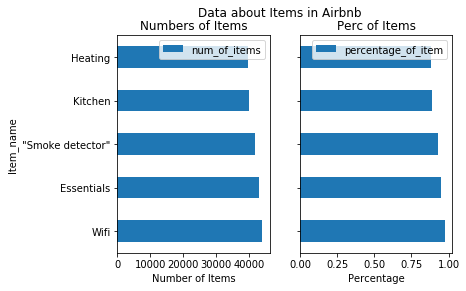

```python
# Your code to answer Question 1
import numpy as np
import pandas as pd
from pandasql import sqldf

df_part2_q1 = pd.read_csv("listings.csv.gz", compression = "gzip")["amenities"].to_list()
return_dict = {}
temp_list = []
# Import data and creat empty lists to store and count the number of items appeared in the amenities

for column in df_part2_q1:
    temp_list = str(column).strip("{}").split(",")
    for item in temp_list:
        if item not in return_dict:
            return_dict.update({item:1})
        elif item in return_dict:
            return_dict[item] += 1
# Split and create the string that store the different items that are included in the listings
# Turn them into a string with duplicates so that the dictionary-count methods can be used on the lists.
# If the item occured in the list, the value of the item will increase by one
# Just like the verification problem

return_part2_q1_df = pd.Series(return_dict, index = return_dict.keys())
return_part2_q1_df = pd.DataFrame(return_part2_q1_df)
return_part2_q1_df.columns = ["num_of_items"]
return_part2_q1_df = return_part2_q1_df.sort_values("num_of_items", axis = 0, ascending = False, inplace = False).head(5)
return_part2_q1_df["percentage_of_item"] = return_part2_q1_df["num_of_items"]/len(df_part2_q1)
print(return_part2_q1_df)
# Turn the dictionary into a series, and then turn it to dataframe of sorting purpose
# Get the percentage of the items appearances for numerical purposes

%matplotlib inline
#Import here plotting here
import pandas as pd
import matplotlib.pyplot as plt
return_part2_q1_df_plot = return_part2_q1_df
return_part2_q1_df_plot["items"] = return_part2_q1_df.index.values
# Used the items as the y axis and created a double barh chart for visulization
# The left of the graph is the num_of_items, and the right of the graph is the percentage

fig, (ax0,ax1) = plt.subplots(nrows = 1, ncols = 2, sharey = True)
return_part2_q1_df_plot.plot(kind = "barh", x = "items", y = "num_of_items",ax = ax0)
ax0.set(title = "Numbers of Items", xlabel = "Number of Items", ylabel = "Item_name")
return_part2_q1_df_plot.plot(kind = "barh", x = "items", y = "percentage_of_item",ax = ax1)
ax1.set(title = "Perc of Items", xlabel = "Percentage", ylabel = "Item_name")
fig.suptitle("Data about Items in Airbnb")
# Plot the data
# Result
```

### Question 2: What is the relationship bewteen price and neiborhood? Which neibourhood has the highest price? Which neibourhood has the lowest price?

```python
# Your code to answer Question 2
import pandas as pd
import numpy as np

#Note: here we used the listings.csv having relatively small volumn downloaded from insideairbnb
df_part2_q2 = pd.read_csv("./small_listings.csv").loc[:,["price","neighbourhood"]]
get_data = lambda x : pd.Series({"mean" : np.mean(x), "std":np.std(x),\
                                          "median" : np.median(x), "most_expensive" : max(x), "cheapest" : min(x),\
                                        "more_time_expensive" : max(x)/min(x)})
# Get the price and the neibourhood out of the listings data, and then calculate them and outputted the result into a series

temp_df = df_part2_q2.groupby("neighbourhood")["price"].mean()
temp_df = pd.DataFrame({"neighbourhood" : temp_df.index, "price" : temp_df.values})
pricing_rank_df = temp_df.sort_values('price', ascending = False, inplace = False)
# Sort the dataframe by the average price


print(pricing_rank_df.head(5))
print(pricing_rank_df.tail(5))
# To get the list of the top 5 most expensive neighbourhood
# And to get the list of the cheapest neigbourhood

detailed_data = get_data(pricing_rank_df.price.to_list())
detailed_data = get_data(pricing_rank_df.price.to_list())
print(detailed_data)
# Above is the result of the overall data of the average price group by neibourhood
# Result
```

```
            neighbourhood        price
182         Rolling Hills  1883.750000
19                Bel-Air  1847.178947
135                Malibu  1606.288714
23          Beverly Crest  1408.620690
103  Hollywood Hills West  1004.282920
             neighbourhood      price
244                  Watts  45.148148
57   Desert View Highlands  45.000000
193       Santa Fe Springs  36.000000
202      South Diamond Bar  30.000000
52                  Cudahy  20.000000
mean                    171.862233
std                     219.671952
median                  118.474576
most_expensive         1883.750000
cheapest                 20.000000
more_time_expensive      94.187500
dtype: float64
```

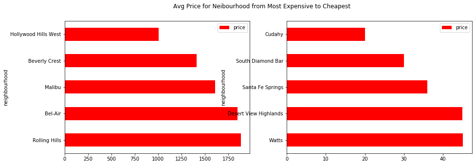

```python
%matplotlib inline

#Import here
import pandas as pd
import matplotlib.pyplot as plt
plot_df_exp = pd.DataFrame(pricing_rank_df.head(5))
plot_df_cheap = pd.DataFrame( pricing_rank_df.tail(5))
fig, (ax0, ax1) = plt.subplots(nrows = 1, ncols = 2, figsize = (15,5))
plot_df_exp.plot(kind = "barh", y = "price", x = "neighbourhood",ax = ax0, color = "r")
plot_df_cheap.plot(kind = "barh", y = "price", x = "neighbourhood",ax = ax1, color = "r")
fig.suptitle("Avg Price for Neibourhood from Most Expensive to Cheapest")
```

### Question 3: What are the percentage discounts of private room against entire rooms?

```
entire_home_apt_avg    288.598637
private_room_avg        85.498959
hotel_room_avg         141.248768
shared_room_avg         55.005088
dtype: float64 entire_home_apt_median    150.0
private_room_median        65.0
hotel_room_median          76.0
shared_room_median         30.0
dtype: float64
```

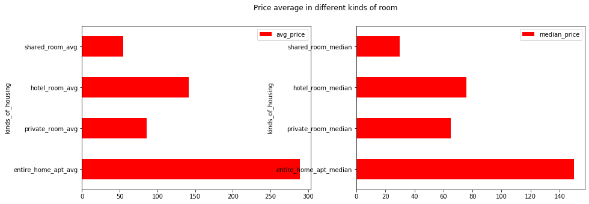

```python
# Your code to answer Question 3
df_part2_q3 = pd.read_csv("./small_listings.csv").loc[:,["price","room_type" ]]
entire_home_apt = []
private_room =[]
hotel_room = []
shared_room = []
# Read in the data
# Created the empty list to store the prices of different type of the room

def get_type(row):
    if row.room_type == "Entire home/apt":
        entire_home_apt.append(row.price)
    elif row.room_type == "Private room":
        private_room.append(row.price)
    elif row.room_type == "Hotel room":
        hotel_room.append(row.price)
    elif row.room_type == "Shared room":
        shared_room.append(row.price)
# Created a new functions to indentify the different types of the listings, and then store the pricing information
# for calculation purposes

df_part2_q3.apply(get_type, axis = 1)
comparison_mean = pd.Series({"entire_home_apt_avg" : np.mean(entire_home_apt), "private_room_avg" : np.mean(private_room),\
                       "hotel_room_avg" : np.mean(hotel_room), "shared_room_avg" : np.mean(shared_room)})
comparison_median = pd.Series({"entire_home_apt_median" : np.median(entire_home_apt), \
                               "private_room_median" : np.median(private_room),\
                       "hotel_room_median" : np.median(hotel_room), "shared_room_median" : np.median(shared_room)})
print(comparison_mean, comparison_median)
# 1. Calculate the average price of different room type to make comparison
# 2. Calculate the median price of different room type to make comparison with the average price of the different
# room type to make sure some of the data are not over-estimated or under-estimated.
# Make calculation on the lists of prices of different room type and then turn them into series

%matplotlib inline
#Import here
import pandas as pd
import matplotlib.pyplot as plt
plot_df_mean = pd.DataFrame(comparison_mean)
plot_df_median = pd.DataFrame(comparison_median)
plot_df_mean.columns = ["avg_price"]
plot_df_median.columns = ["median_price"]
fig, (ax0, ax1) = plt.subplots(nrows = 1, ncols = 2, figsize = (15,5))
plot_df_mean["kinds_of_housing"] = plot_df_mean.index.values
plot_df_median["kinds_of_housing"] = plot_df_median.index.values
plot_df_mean.plot(kind = "barh", y = "avg_price", x = "kinds_of_housing",ax = ax0, color = "r")
plot_df_median.plot(kind = "barh", y = "median_price", x = "kinds_of_housing",ax = ax1, color = "r")
# Plot the series into the graph
# 1. The left is the average price per room type
# 2. The right is the median price per room type

fig.suptitle("Price average in different kinds of room")
# Result
```

### Question 4: What are the 10 most common words appearing in the description of listings which have the top 1% review score? Try to visualize it.

```python
# Your code to answer Question 4
import nltk
from nltk.corpus import stopwords
from nltk.tokenize import word_tokenize
import string
from wordcloud import WordCloud
import matplotlib.pyplot as plt

#Set strings, numbers, etc, that I want to get rid of
stop_words = set(stopwords.words('english'))
#set_temp contains frequent but relatively unimportant words in the description, along with numbers
set_temp = set(['room', 'home', 'house', 'kitchen', 'bedroom', 'bathroom', '0', '1', '2', '3', '4', '5', '6'\
               '7', '8', '9'])
stop_words = stop_words.union(set_temp)
punctuations = set(string.punctuation)

df_listing = pd.read_csv("listings.csv")
df_listing = df_listing[['id', 'name', 'description', 'review_scores_rating']]

#choose rows with review ratings in the top 1%
df_listing = df_listing[df_listing['review_scores_rating'] >= df_listing['review_scores_rating'].quantile(0.99)]

#create a copy, for the convenience of debug, so that we don't need to read csv file again, which is time-consuming
df_listing_temp = df_listing.copy()

#clean the 'description' column
for index, row in df_listing_temp.iterrows():
    description_nonstopwords = ' '
    description = str(row["description"])

    description_nonpunctuations = ''.join(w.lower() for w in description if w not in punctuations).split(" ")
    for w in description_nonpunctuations:
        if w not in stop_words:
            description_nonstopwords = description_nonstopwords + ' ' + w
    df_listing_temp.loc[index, 'description'] = description_nonstopwords

#get the top 10 words
top10words = pd.Series(' '.join(df_listing_temp['description']).lower().split()).value_counts()[:10]
top10words
```

```
private        6519
beach          4723
hollywood      4699
located        4446
living         4409
parking        4349
restaurants    4175
apartment      4073
space          4072
bed            4029
dtype: int64
```

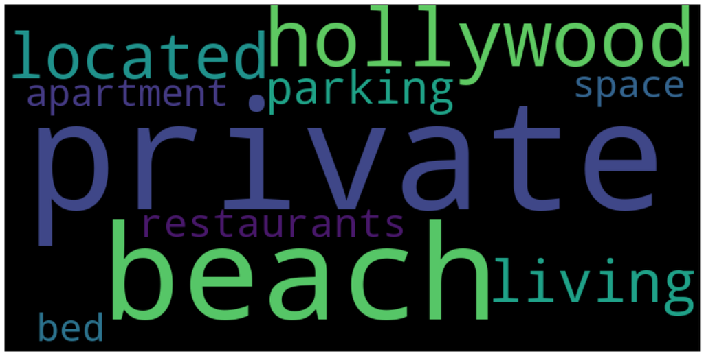

```python
#visualize the top 10 words
top10words = pd.DataFrame(top10words).reset_index().rename(columns={'index': 'word', 0:'count'})
top10words_dict = dict(zip(top10words['word'], top10words['count']))
top10words_wc = WordCloud(width=800, height=400)
top10words_wc.generate_from_frequencies(frequencies=top10words_dict)
plt.figure(figsize=(30,10))
plt.imshow(top10words_wc, interpolation="bilinear")
plt.axis("off")
plt.show()
```

### Question 5: Consider the most common number of vistors in a reservation, which is 2. Suppose there is a young couple traveling to LA and have a budget of 100 dollars per night, how would you help them choose the listing to stay? Try to narrow down the scope of choices.

```python
# Your code to answer Question 5
import pandas as pd
import folium
from folium.plugins import HeatMap

df_listings = pd.read_csv('listings.csv')

#clean price data
df_listings['price'] = df_listings['price'].str.replace("$", "").str.replace(",","").astype(float)
#create a copy, for the convenience of debug, so that we don't need to read csv file again, which is time-consuming
df_listings_copy = df_listings.copy()

#filter rows
#choose listings accommodating specifically two visitors
df_listings_copy = df_listings_copy[df_listings_copy['accommodates']==2]
#choose listings having the top 1% review rating
df_listings_copy = df_listings_copy[df_listings_copy['review_scores_rating']>=\
                                    df_listings_copy['review_scores_rating'].quantile(0.99)]
#choose listings whose host is superhost
df_listings_copy = df_listings_copy[df_listings_copy['host_is_superhost']=='t']
#choose listings having prices above median but not exceeding the budget
df_listings_copy = df_listings_copy[(df_listings_copy['price']<=100) & \
                                    (df_listings_copy['price']>=df_listings_copy['price'].quantile(0.5))]
```

```python
#plot the map
lats = df_listings_copy['latitude'].tolist()
lons = df_listings_copy['longitude'].tolist()
locations = list(zip(lats, lons))

LA_map = folium.Map(location=[34.0522, -118.2437], zoom_start=11)

#create a feature group
prices = folium.map.FeatureGroup()
#add listing locations to the feature group
for lat, lon, in zip(lats, lons):
    prices.add_child(
        folium.CircleMarker(
            [lat, lon],
            radius=7, # define how big you want the circle markers to be
            color='green',
            fill=True,
            fill_color='lightblue',
            fill_opacity=0.4
        )
    )

#add feature group to map
LA_map.add_child(prices)
```

[interactive chart not shown]

```python
#create labels for the pins
labels = list(df_listings_copy['price'])
#add labels to the feature group
for lat, lon, label in zip(lats, lons, labels):
    folium.Marker([lat, lon], popup=label).add_to(LA_map)

LA_map
```

[interactive chart not shown]

```python
#Create a heatmap to show the distribution of listings
LA_map_2 = folium.Map(location = [34.0522, -118.2437], zoom_start = 10)
HeatMap(locations).add_to(LA_map_2)

LA_map_2
```

[interactive chart not shown]

## Executive Summary

**(You need to use this cell to write your executive summary)**

### Recommendation 1:

We recommend the enforcement of installing smoke detectors to all the listings for safety purposes.

### Note 2:

For the second problem, our team was trying to find details about the average pricing of the Airbnb listing by neighborhood. We grouped the data by using neighborhood, and then take the mean of the price of all the listings. The data is concise and easy to follow: For the top 5 most expensive neighborhood, the average price is around 1500 +- 300. The most costly neighborhood is Rolling Hills, with the price around 1880$ per night, Bei-Air and Beverly following after. The reason is because there are not many apartments around that neighborhood, instead, they are mainly housed with a lot of rooms and carefully decorated. So the price is significantly higher. To the cheapest neighborhood, it is mainly around the ghetto. Most of them are shared rooms or private rooms, for people that are looking for a quick stay instead of a vacation. When it comes to comparison, the most expensive listing in Rolling Hills is 94 times more expensive than the listing in Cudahy.

### Recommendation 2:

We suggest that a more detailed recommendation system be created. The system categorizes listings in different price range for people who have made similar past purchase. For people who rent apartment such as the one on Rolling Hilling, it is likely that the customer want a sense of the Hollywood lifestyle. So next time when they go to a different city, they might be interested in the richest and most resemble area of the city.

### Recommendation 3:

We recommend that when homeowners post their listing over the Airbnb, a suggested price range should pop up so the poster has a general understanding of what price range of his/her posting should fall on, to attract the most customer and to make it most appealing.

### Note 4:

Across all the times, the 10 most popular words for listings receiving the top 1 percent review scores are private, beach, Hollywood, located, living, parking, restaurants, apartment, space, bed, which indicate the best attractions of LA for visitors such as Hollywood and beach. And for the listings themselves, it is important to have private space and a great location near parking lots and restaurants. Among all the listing type, apartment is the most common instead of condos or others. With these ten words, we can get a general idea of LA: a sunny city close to beaches and Hollywood; a great place to hang out and enjoy different food; visitors traveling here prefer private spaces and will most likely find apartments as the most common type of listings they can find on Airbnb. One interesting thing is, Airbnb starts with the idea of 'sharing space,' but the market itself has chosen to let the private spaces become the most common type of listings. Therefore, the sharing idea of Airbnb may be somewhat unsubstantial; the essential form of this business may be just another version of 'traditional' renting services.

### Recommendation 4:

For the landlords, it is better to design listings with private spaces and close to attractions, in order to get more competitive.

### Note 5:

After choosing the rows with accommodations == 2 people, I filtered the rows with top 1 percent review scores, finding out that quantile is already 100 out of 100, indicating many customers would rate highly on the listings. It is quite common that a listing gets full score. In order to narrow down the scope of choices, I chose listings whose hosts are superhosts, which is a common filter that visitors would consider. I then chose rows with price above the median but lower than the budget, and created a map to pin those listings after all these filters on the map. The maps are interactive. By clicking the popups the visitors can see the price, and they can directly find out where the listing is, whether located in the downtown or near the beaches or Hollywood. By drawing the heatmap, we can see that the listings satisfying all these filters mostly gather in the downtown area or near from the beaches. On the other hand, they can also spread across the whole city, so the visitors would always find a place to stay near where they want to visit. An interesting thing is, the frequent appearances of these listings in the downtown area shows the downtown may be actually not a common place for locals to live, so landlords rent them out, which is excellent for visitors.

### Recommendation 5:

For a couple with a budget of 100 dollars, we give our recommendations displayed in the map. These houses are within the budget, close to attractions, and have superhosts, which are great choices.